# Model checking and validation

Model fitting and inference for infectious disease dynamics

# Recap

## Where we are

In the last session we asked whether the **sampler** worked: R̂, effective sample size, trace plots, divergences.

A converged chain tells you the algorithm did its job.

It says nothing about whether the **model** is any good.

You can have a perfectly converged posterior for a model that cannot possibly have produced your data.

## Two different questions

|  | Question | Tools |
| --- | --- | --- |
| **Diagnostics** | Did the algorithm work? | R̂, ESS, trace plots, divergences |
| **Model checking** | Does the model make sense? | Prior and posterior predictive checks, residuals, SBC |

This session is about the second row.

# The Bayesian workflow

## Model building is a loop

Model checking is not a step at the end. Gelman et al. (2020) describe fitting as an iterative **workflow**:

Specify model Prior predictive check Fit Diagnose sampler Posterior predictive check

↺ if the checks fail, revise the model and go round again

So far the course has covered specifying, fitting and diagnosing. This session covers the two checking steps, and what to do when they fail.

## Why bother?

- A model that fits badly will give you **confidently wrong** answers.
- Convergence diagnostics cannot detect a misspecified likelihood, a missing mechanism, or priors that rule out the truth.
- Checking is cheap relative to the cost of publishing a wrong estimate.

The aim is not to prove the model is *correct*. Every model is wrong. The aim is to find the ways in which it is wrong that **matter for the question you are asking**.

# Prior predictive checks

## Before you see the data

A prior predictive check simulates data from the model using parameters drawn from the **prior alone**.

$$\theta^{(i)} \sim p(\theta), \qquad y^{(i)} \sim p(y \mid \theta^{(i)})$$

Then ask: do these simulated epidemics look like something that could plausibly happen?

## What it catches

- Priors that put weight on **impossible** outcomes — attack rates above 100%, epidemics lasting decades, negative durations.
- Priors that are **far too vague**, so the model considers almost anything possible and the data have to do all the work.
- Priors that are **accidentally informative**, ruling out the truth before you start.

This is the cheapest check in the workflow: it needs no data and no fitting.

## A warning about vague priors

“Uninformative” priors are rarely uninformative on the scale you care about.

A flat prior on $R_0$ from 1 to 20 sounds humble. Push it through the model and most of that range produces epidemics that infect the entire population within a fortnight.

Vague on the parameter is not vague on the outcome.

# Posterior predictive checks

## After fitting

A posterior predictive check simulates data using parameters drawn from the **posterior**:

$$\theta^{(i)} \sim p(\theta \mid y), \qquad y^{\text{rep},(i)} \sim p(y \mid \theta^{(i)})$$

If the model is adequate, the observed data should look like a typical draw from this distribution, not an outlier.

## What to look for

- Does the **timing** of the peak match?
- Is the **height** of the peak captured?
- Is the **shape** right, or does the model systematically over- or under-shoot at particular times?
- Is the **spread** of the replicated data plausible, or is the observed series suspiciously smooth or suspiciously noisy by comparison?

## Posterior predictive p-values

Pick a summary statistic $T(y)$ — peak height, epidemic duration, final size — and compare the observed value against its distribution under replication:

$$p_B = \Pr\big(T(y^\text{rep}) \geq T(y) \mid y\big)$$

- Values near 0.5 mean the observed data are typical for that statistic.
- Values near 0 or 1 mean the model systematically misses that feature.

These are **not** frequentist p-values and should not be thresholded at 0.05. They are a diagnostic for “which feature is my model missing”, not a test.

## Residuals: observed minus predicted, over time

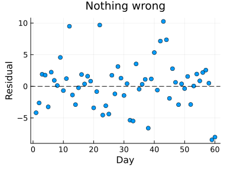

Scattered about zero, spread the same throughout.

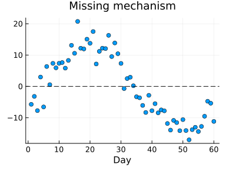

Runs above then below zero: the model is wrong, not just noisy.

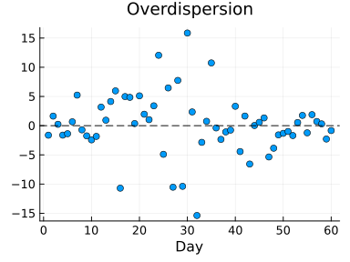

Spread grows with the prediction: try a negative binomial.

Autocorrelation in the residuals breaks the conditional-independence assumption in the likelihood.

# Simulation-based calibration

## Checking the whole machinery

Predictive checks compare the model to *one* dataset. Simulation-based calibration (Talts et al. 2018) checks whether the inference is correct on average, across datasets:

1. Draw $\theta^\text{true} \sim p(\theta)$
2. Simulate data $y \sim p(y \mid \theta^\text{true})$
3. Fit the model to $y$ and obtain posterior samples
4. Record the **rank** of $\theta^\text{true}$ among those samples
5. Repeat many times

If the model and sampler are working, those ranks are **uniformly distributed**.

## Reading an SBC histogram

- **Uniform** — inference is calibrated
- **∪-shaped** — posteriors too narrow, overconfident
- **∩-shaped** — posteriors too wide, underconfident
- **Sloped** — systematic bias in one direction

SBC is expensive: it means fitting the model hundreds of times. Reserve it for models you intend to rely on repeatedly.

# When checks fail

## What to do

Failure is information. In rough order of what to try:

1. **Revisit the observation model** — overdispersion, under-reporting, reporting delays. Often the cheapest fix.
2. **Revisit the priors** — are they excluding the region the data prefer?
3. **Revisit the structure** — is there a mechanism the model is missing? Waning immunity, age structure, time-varying transmission.
4. **Revisit the data** — are the observations really what you think they are?

Resist the temptation to keep adding parameters until the fit looks good. A model that fits everything predicts nothing.

## When is a model good enough?

There is no threshold. The honest answer is: when it captures the features relevant to the question, and you understand the ways it does not.

Document the checks you ran, including the ones that failed. A reader who knows where the model breaks can judge how far to trust it. A reader shown only the good plots cannot.

## Your Turn

In the practical you will

- run prior predictive checks and see what vague priors actually imply
- generate posterior predictive distributions with `predict` and `decondition`
- compute posterior predictive p-values for several summary statistics
- inspect residuals for structure and autocorrelation

Simulation-based calibration is written up at the end, to work through afterwards.

Return to the session